# Reshaping tables

> Change layout of values in a table

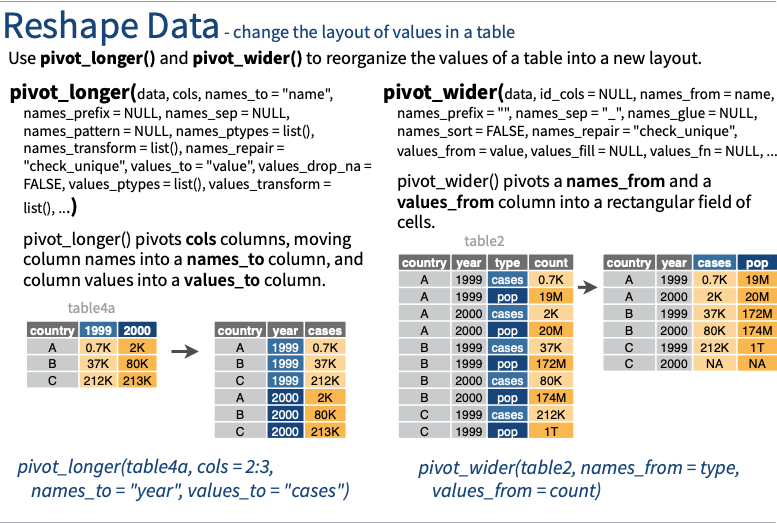

*Source:* [data import cheat sheet : tidyr](https://www.rstudio.com/resources/cheatsheets/)

Two main functions to manipulate the layout of the table, `pivot_longer` transforms the table from wide to long format and `pivot_wider`, which does the opposite, converts the table from long to wide format.

## `pivot_longer` : wide to long format

This function allows collapsing ‘similar’ variables into one variable while guaranteeing the data set’s consistency. For example take the variables `pulse1` and `pulse2` in the following subset of the pulse data set:

```r
pulses <- pulse  %>%
      select(name,pulse1,pulse2)  %>%
      head(3)
pulses
```

```
# A tibble: 3 x 3
  name     pulse1 pulse2
  <chr>     <dbl>  <dbl>
1 Bonnie       86     88
2 Melanie      82    150
3 Consuelo     96    176
```

We can transform the table as such that all pulse values are under a single variable, say `pulse`:

```r
dfLong <- pulses %>% pivot_longer(c(pulse1, pulse2), names_to = "pulse", values_to = "level")
dfLong
```

```
# A tibble: 6 x 3
  name     pulse  level
  <chr>    <chr>  <dbl>
1 Bonnie   pulse1    86
2 Bonnie   pulse2    88
3 Melanie  pulse1    82
4 Melanie  pulse2   150
5 Consuelo pulse1    96
6 Consuelo pulse2   176
```

This is called the long version of the original (wide) table and contains the same information.

Alternatively you achieve the same result using `!` (negation operator):

```r
dfLong <- pulses %>% pivot_longer(!name, names_to = "pulse", values_to = "level")
dfLong
```

```
# A tibble: 6 x 3
  name     pulse  level
  <chr>    <chr>  <dbl>
1 Bonnie   pulse1    86
2 Bonnie   pulse2    88
3 Melanie  pulse1    82
4 Melanie  pulse2   150
5 Consuelo pulse1    96
6 Consuelo pulse2   176
```

> Can you find ohter variables in the pulse data set which can be transformed to long format?

Answer

Yes, for example smokes and alcohol, both are categorical with values {yes,no}.

Let’s reshape the pulse dataset with variables `drug` = {smokes,alcohol} and `use` = {yes,no}.

```r
pulse %>%  pivot_longer(c(smokes,alcohol), names_to = "drug", values_to = "use")
```

```
# A tibble: 220 x 13
   id     name     height weight   age gender exercise ran   pulse1 pulse2  year drug    use
   <chr>  <chr>     <dbl>  <dbl> <dbl> <chr>  <chr>    <chr>  <dbl>  <dbl> <dbl> <chr>   <chr>
 1 1993_A Bonnie      173     57    18 female moderate sat       86     88  1993 smokes  no
 2 1993_A Bonnie      173     57    18 female moderate sat       86     88  1993 alcohol yes
 3 1993_B Melanie     179     58    19 female moderate ran       82    150  1993 smokes  no
 4 1993_B Melanie     179     58    19 female moderate ran       82    150  1993 alcohol yes
 5 1993_C Consuelo    167     62    18 female high     ran       96    176  1993 smokes  no
 6 1993_C Consuelo    167     62    18 female high     ran       96    176  1993 alcohol yes
 7 1993_D Travis      195     84    18 male   high     sat       71     73  1993 smokes  no
 8 1993_D Travis      195     84    18 male   high     sat       71     73  1993 alcohol yes
 9 1993_E Lauri       173     64    18 female low      sat       90     88  1993 smokes  no
10 1993_E Lauri       173     64    18 female low      sat       90     88  1993 alcohol yes
# … with 210 more rows
```

## `pivot_wider` : long to wide format

```r
dfWide <- dfLong %>% pivot_wider(names_from = "pulse", values_from = "level")
dfWide
```

```
# A tibble: 3 x 3
  name     pulse1 pulse2
  <chr>     <dbl>  <dbl>
1 Bonnie       86     88
2 Melanie      82    150
3 Consuelo     96    176
```

> Below, pulses tibble has been transformed into pulses2. What can you say about this transformation?

```r
pulses2 <- pulses %>%
           pivot_longer(!name, names_to = "pulse", values_to = "level") %>%
           pivot_wider(names_from = "pulse", values_from = "level")
```

Answer

pulses and pulses2 are identical